# R Readiness Assignment

Introduction to R, RStudio, and ggplot

There are many ways to use R to answer these questions. The important thing, is not whether what you did matches what I did exactly, but rather whether we end up at the same place (e.g., do our plots look the same, are we getting the same computed result).

# Part I

**1. Use the `data.frame()` function to enter these data into a data frame called `reading`. There should be two columns in the data frame. The first column you should name `month` and the second should be named `pages`.**

```r
reading = data.frame(
  month = c("January", "February", "March", "April", "May", "June", "July",
            "August", "September", "October", "November", "December"),
  pages = c(1453, 422, 848, 1679, 1655, 1630, 710, 557, 978, 920, 647, 2698)
  )

reading
```

```
##        month pages
## 1    January  1453
## 2   February   422
## 3      March   848
## 4      April  1679
## 5        May  1655
## 6       June  1630
## 7       July   710
## 8     August   557
## 9  September   978
## 10   October   920
## 11  November   647
## 12  December  2698
```

Note there is also a default object in R called `month.name`. This could be used rather than typing each of the months. Similarly there is also a built in R object called `month.abb` that could be used.

```r
month.name
```

```
##  [1] "January"   "February"  "March"     "April"     "May"
##  [6] "June"      "July"      "August"    "September" "October"
## [11] "November"  "December"
```

```r
month.abb
```

```
##  [1] "Jan" "Feb" "Mar" "Apr" "May" "Jun" "Jul" "Aug" "Sep" "Oct" "Nov"
## [12] "Dec"
```

```r
reading2 = data.frame(
  month = month.name,
  pages = c(1453, 422, 848, 1679, 1655, 1630, 710, 557, 978, 920, 647, 2698)
  )

reading2
```

```
##        month pages
## 1    January  1453
## 2   February   422
## 3      March   848
## 4      April  1679
## 5        May  1655
## 6       June  1630
## 7       July   710
## 8     August   557
## 9  September   978
## 10   October   920
## 11  November   647
## 12  December  2698
```

**2. Use the `sum()` function to find the total number of pages Andy read in 2013.**

```r
sum(reading$pages)
```

```
## [1] 14197
```

**3. Use the `sm.density()` function from the** sm** package to create a density plot of the marginal distribution of `pages`.**

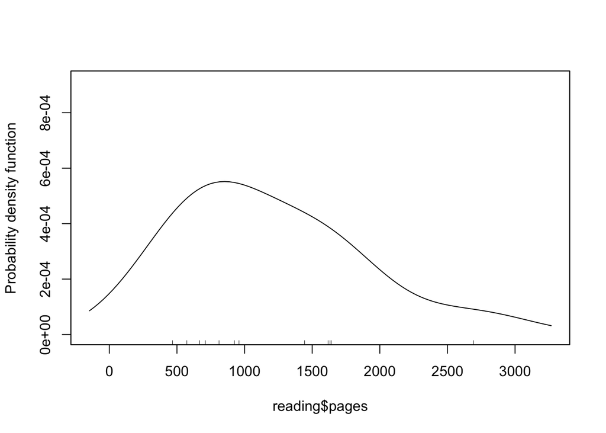

```r
library(sm)
sm.density(reading$pages)
```

*Figure 1.* Density plot of the marginal distribution of pages read.

**4. Use the `describe()` function from the** psych** package to summarize the marginal distribution of `pages`.**

```r
library(psych)
describe(reading$pages)
```

```
##   vars  n    mean     sd median trimmed   mad min  max range skew kurtosis
## 1    1 12 1183.08 656.59    949  1107.7 664.2 422 2698  2276 0.82    -0.28
##       se
## 1 189.54
```

**5. Enter the following syntax:**

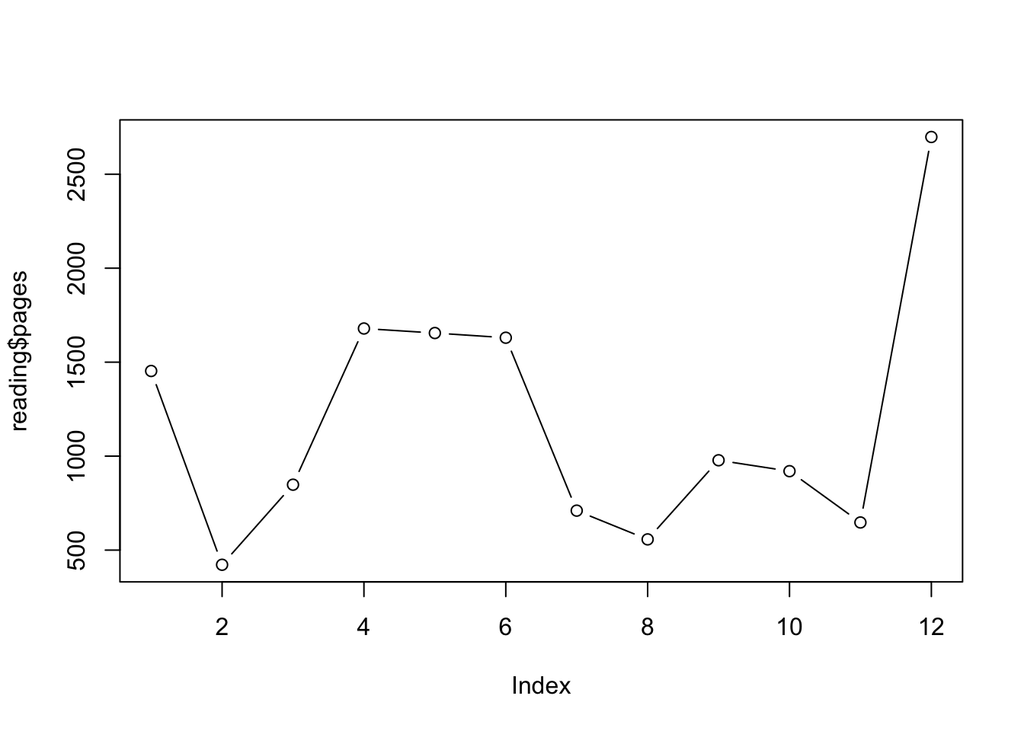

```r
plot(reading$pages, type = "b")
```

**6. Explain in 1–2 sentences what the plot shows.**

The plot shows the number of pages read for each month of the year (index 1 = January, etc.). The pattern is cyclic suggesting that Andy reads more during late spring (Apr–June) and also in December.

# Part II

Use RStudio to open the dataset and assign it into an object called `read`. Use the data to answer the following questions.

Enter the following syntax.

```r
read = read.csv(file = "~/Documents/GitHub/EPsy-8251/data/GoodReads-2016.csv")

library(dplyr)
p = read %>%
  filter(bookshelf == "read") %>%
  group_by(month_read) %>%
  summarize(pages = sum(pages))
p
```

```
## Source: local data frame [12 x 2]
##
##    month_read pages
##        (fctr) (int)
## 1       April  5899
## 2      August  5692
## 3    December 11090
## 4    February  5742
## 5     January  8251
## 6        July  6864
## 7        June  8014
## 8       March  5105
## 9         May  7727
## 10   November  5465
## 11    October  4031
## 12  September  5210
```

**7. Explain (in no more than 5 sentences) what the `filter()`, `group_by()` and `summarize()` syntax does in the syntax above.**

The `filter()` function only uses rows of the original data that have a `bookshelf` value of `read`. The `group\_by()` syntax groups together rows with common values in the `month_read` variable. The `summarize()` syntax is used to create summaries based on the computations listed, in this case, summing the pages read for each month.

# Part III

**8. Using `ggplot()`, create a lineplot (similar to the plot seen [here](http://www.statcrunch.com/grabimageforreport.php?reportid=5139&image_id=374579). This plot should show the total number of pages read per month. The plot should include points and lines as in the example. It should also be displayed chronologically (e.g., January should be the first month).**

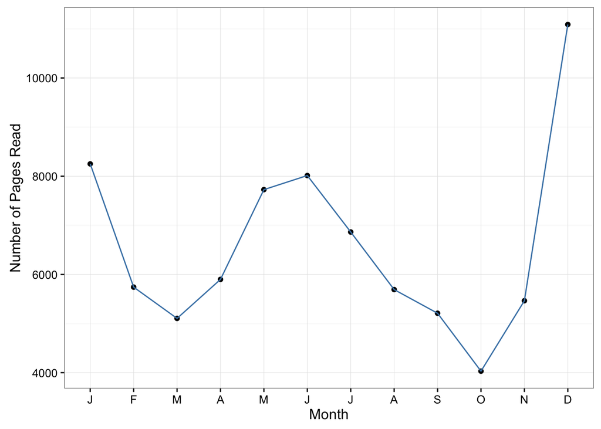

```r
library(ggplot2)
p$month = factor(p$month_read, levels = month.name)

ggplot(data = p, aes(x = month, y = pages, group = 1)) +
  geom_point() +
  geom_line(color = "steelblue") +
  xlab("Month") +
  ylab("Number of Pages Read") +
  scale_x_discrete(
    labels = c("J", "F", "M", "A", "M", "J", "J", "A", "S", "O", "N", "D")
    ) +
  theme_bw()
```

*Figure 3.* Number of pages read per month for the years 2010-2016.

# Part IV

**9. Change the dplyr syntax from above to compute (1) the average number of pages read per month—rather than the total number read per month; and (2) the standard deviation of the pages read per month. (Hint: The output should be a data frame with three columns rather than two columns.)**

```r
p2 = read %>%
  filter(bookshelf == "read") %>%
    group_by(month_read) %>%
    summarize(M = mean(pages), SD = sd(pages))
p2
```

```
## Source: local data frame [12 x 3]
##
##    month_read        M        SD
##        (fctr)    (dbl)     (dbl)
## 1       April 294.9500  84.34171
## 2      August 379.4667 190.82111
## 3    December 426.5385 187.94068
## 4    February 319.0000  87.74763
## 5     January 305.5926 110.22992
## 6        July 381.3333 190.55646
## 7        June 333.9167 133.19320
## 8       March 319.0625 138.68596
## 9         May 351.2273 136.12212
## 10   November 341.5625 205.65537
## 11    October 366.4545 141.51916
## 12  September 434.1667 257.92065
```

**10. Using `ggplot()`, create a mean-and-error-bar plot (i.e., Tie-Fighter plot) similar to the [plot seen here](http://www.cookbook-r.com/Graphs/Plotting_means_and_error_bars_%28ggplot2%29/). Be sure the plot has appropriate axes and labels, and is numbered and has a caption. Include this plot in a word-processed document. Resize the plot so it does not take up any more space than neccesary and add an appropriate caption.**

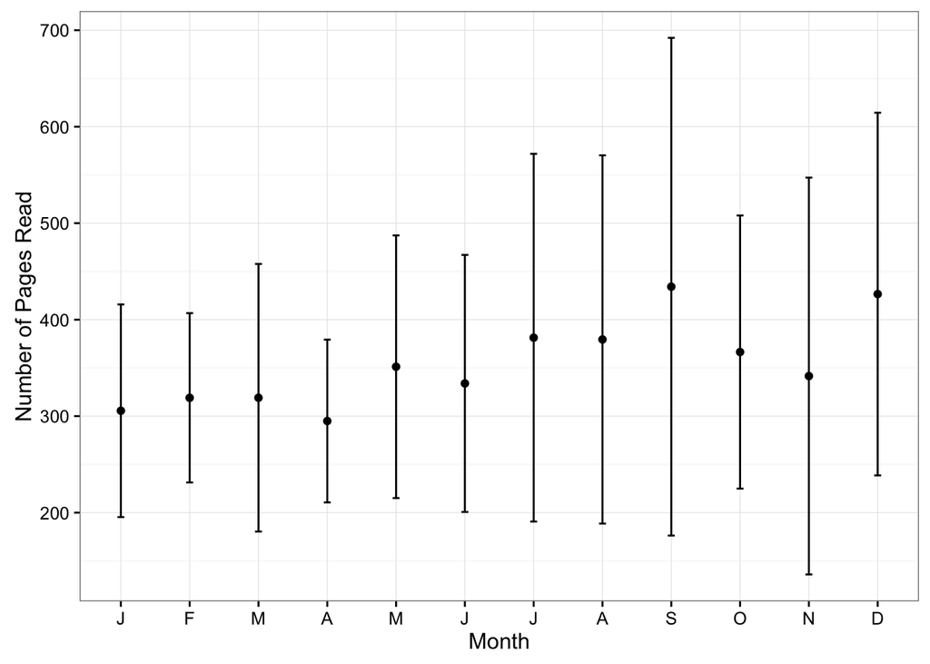

```r
p2$month = factor(p2$month_read, levels = month.name)
ggplot(data = p2, aes(x = month, y = M)) +
    geom_errorbar(aes(ymin = M-SD, ymax = M+SD), width = 0.1) +
    geom_point() +
    xlab("Month") +
    ylab("Number of Pages Read") +
    scale_x_discrete(
        labels = c("J", "F", "M", "A", "M", "J", "J", "A", "S", "O", "N", "D")
        ) +
     theme_bw()
```

*Figure 4.* Mean number of pages read per month (dot) for the years 2010-2016. The variation is diplayed using error bars that extend one standard deviation from the mean.

# Part V

**11. Again change the dplyr syntax from above to compute the average number of pages read per month—rather than the total number read per month (you do not need the standard deviation of the pages read per month this time). This time however, also group the output by year. (Hint: The output should again be a data frame with three columns.)**

```r
p3 = read %>%
  filter(bookshelf == "read") %>%
    group_by(month_read, year_read) %>%
    summarize(M = mean(pages))
p3
```

```
## Source: local data frame [62 x 3]
## Groups: month_read [?]
##
##    month_read year_read        M
##        (fctr)     (int)    (dbl)
## 1       April      2011 330.6667
## 2       April      2012 237.3333
## 3       April      2013 279.8333
## 4       April      2014 343.6667
## 5       April      2015 297.0000
## 6      August      2011 304.0000
## 7      August      2012 311.5000
## 8      August      2013 278.5000
## 9      August      2014 418.4000
## 10     August      2015 423.2000
## ..        ...       ...      ...
```

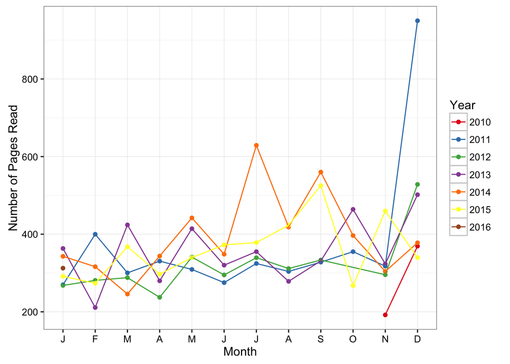

```r
p3$month = factor(p3$month_read, levels = month.name)
ggplot(data = p3, aes(x = month, y = M, color = factor(year_read), group = factor(year_read))) +
    geom_point() +
    geom_line() +
    xlab("Month") +
    ylab("Number of Pages Read") +
    scale_x_discrete(
       labels = c("J", "F", "M", "A", "M", "J", "J", "A", "S", "O", "N", "D")
        ) +
    scale_color_brewer(name = "Year", palette = "Set1") +
     theme_bw()
```

*Figure 5.* Lineplot of the number of pages read per month for each year from 2010 to 2016.